# W16D7 - Buccarini Giacomo Es7

Esercizio Sul database titanic, effettuiamo le seguenti analisi: 1• Quanti ponti c'erano sulla nave? 2• Visualizzare un grafico con il numero di passeggeri di ogni classe di imbarco 3• Fare la stessa cosa per la colonna alive 4• Qual era la distribuzione delle tariffe (fare)? 5• Riusciamo a vedere la distribuzione delle età dei passeggeri rispetto alla classe di imbarco? Proviamo con un boxplot e con un violinplot 6• Visualizziamo un boxplot rispetto alle colonne fare e survived; che cose ne deduciamo?

```python
#import pandas as pd
#import seaborn as sns
#titanic = sns.load_dataset("titanic")
#titanic

from sqlalchemy import create_engine
import dotenv
import os
import pandas as pd
dotenv.load_dotenv(override=True)
username = os.getenv('username')
password = os.getenv('password')
host = os.getenv('host')
dbname = "Titanic" #os.getenv('dbname')


conn_string = f"mysql+pymysql://{username}:{password}@{host}/{dbname}"
db_engine = create_engine(conn_string)
query = """SELECT *  FROM titanic"""
titanic = pd.read_sql(query, db_engine)
titanic
```

|  | PassengerId | PClass | Name | Sex | Age | SibSp | Parch | Ticket | Fare | Cabin | Embarked | Survived | EmbarkDate |
| --- | --- | --- | --- | --- | --- | --- | --- | --- | --- | --- | --- | --- | --- |
| 0 | 1 | 3 | Braund, Mr. Owen Harris | male | 22.0 | 1 | 0 | A/5 21171 | 7.25 |  | S | 0 | 10-4-1912 |
| 1 | 2 | 1 | Cumings, Mrs. John Bradley (Florence Briggs Th... | female | 38.0 | 1 | 0 | PC 17599 | 71.28 | C85 | C | 1 | 11-4-1912 |
| 2 | 3 | 3 | Heikkinen, Miss. Laina | female | 26.0 | 0 | 0 | STON/O2. 3101282 | 7.93 |  | S | 1 | 10-4-1912 |
| 3 | 4 | 1 | Futrelle, Mrs. Jacques Heath (Lily May Peel) | female | 35.0 | 1 | 0 | 113803 | 53.10 | C123 | S | 1 | 10-4-1912 |
| 4 | 5 | 3 | Allen, Mr. William Henry | male | 35.0 | 0 | 0 | 373450 | 8.05 |  | S | 0 | 10-4-1912 |
| ... | ... | ... | ... | ... | ... | ... | ... | ... | ... | ... | ... | ... | ... |
| 1304 | 1305 | 3 | Spector, Mr. Woolf | male | 0.0 | 0 | 0 | A.5. 3236 | 8.05 |  | S | 0 | 10-4-1912 |
| 1305 | 1306 | 1 | Oliva y Ocana, Dona. Fermina | female | 39.0 | 0 | 0 | PC 17758 | 108.90 | C105 | C | 1 | 11-4-1912 |
| 1306 | 1307 | 3 | Saether, Mr. Simon Sivertsen | male | 38.5 | 0 | 0 | SOTON/O.Q. 3101262 | 7.25 |  | S | 0 | 10-4-1912 |
| 1307 | 1308 | 3 | Ware, Mr. Frederick | male | 0.0 | 0 | 0 | 359309 | 8.05 |  | S | 0 | 10-4-1912 |
| 1308 | 1309 | 3 | Peter, Master. Michael J | male | 0.0 | 1 | 1 | 2668 | 22.36 |  | C | 1 | 11-4-1912 |

1309 rows × 13 columns

```python
#1
titanic.Parch.value_counts()
```

```
Parch
0    1002
1     170
2     113
3       8
5       6
4       6
6       2
9       2
Name: count, dtype: int64
```

```python
#2
titanic.PClass.value_counts()
```

```
PClass
3    709
1    323
2    277
Name: count, dtype: int64
```

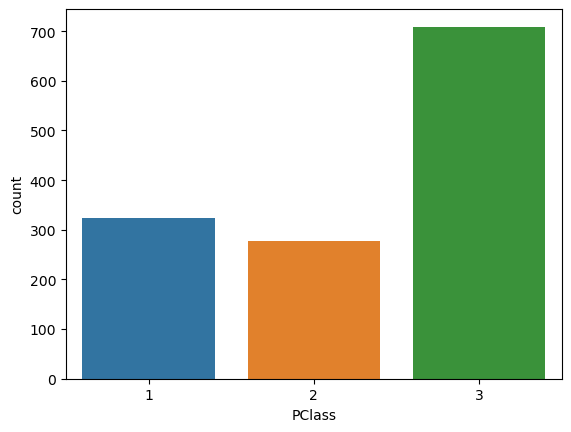

```python
#2
sns.countplot(data=titanic, x="PClass")
```

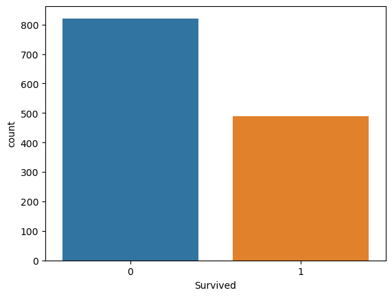

```python
#3
sns.countplot(data=titanic, x="Survived")
```

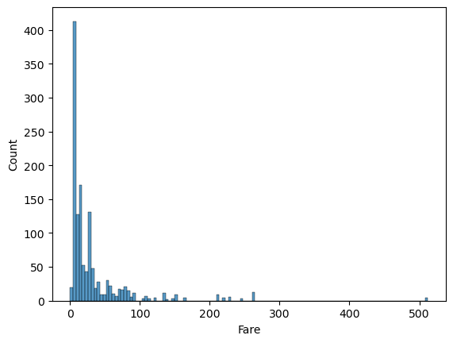

```python
#4
sns.histplot(data=titanic, x="Fare")
```

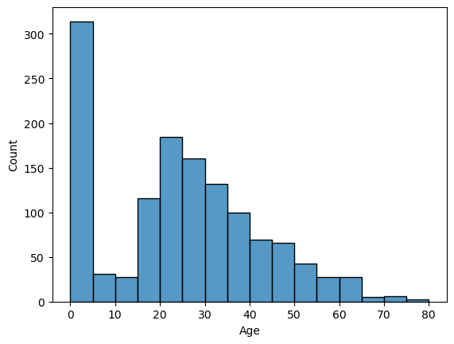

```python
#5
sns.histplot(data=titanic, x="Age")
```

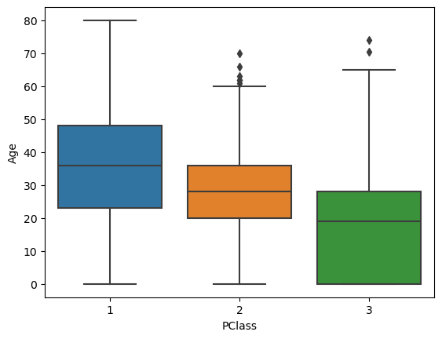

```python
sns.boxplot(data=titanic, x="PClass", y="Age")
```

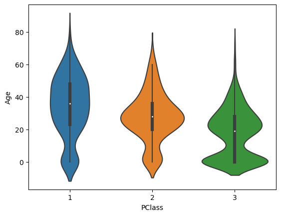

```python
sns.violinplot(data=titanic, x="PClass", y="Age")
```

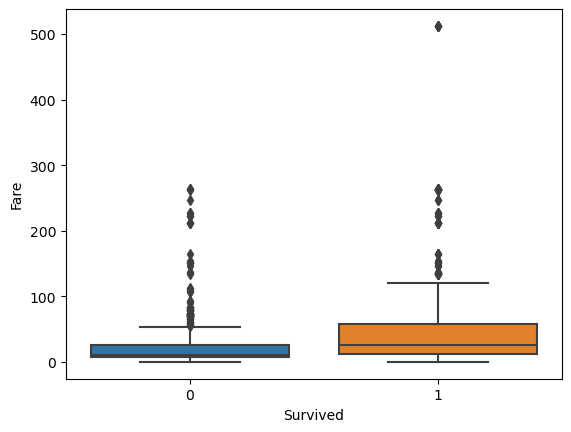

```python
#6
sns.boxplot(data=titanic, x="Survived", y="Fare")
```

Esercizio Scarichiamo il dataset stockdata.csv da https://github.com/plotly/datasets/blob/master/stockdata.csv e: 7• Visualizziamo l'andamento delle azioni della Apple ("AAPL") 8• Visualizziamo l'andamento di tutte le azioni del dataset 9• Visualizziamo l'andamento di Microsoft ("MSFT") e IBM ("IBM") negli anni 2012 e 2013 10• Con un istogramma, troviamo il range di valori che le azioni di Microsoft hanno assunto più spesso

```python
stock = pd.read_csv("stockdata.csv")
stock
stock = stock.set_index("Date")
stock
```

| Date | MSFT | IBM | SBUX | AAPL | GSPC |
| --- | --- | --- | --- | --- | --- |
| 2007-01-03 | 23.950705 | 80.517962 | 16.149666 | 11.086612 | 1416.599976 |
| 2007-01-04 | 23.910599 | 81.378851 | 16.167992 | 11.332687 | 1418.339966 |
| 2007-01-05 | 23.774242 | 80.642129 | 16.099269 | 11.251984 | 1409.709961 |
| 2007-01-08 | 24.006852 | 81.867244 | 16.039710 | 11.307550 | 1412.839966 |
| 2007-01-09 | 24.030914 | 82.835742 | 15.970989 | 12.246870 | 1412.109985 |
| ... | ... | ... | ... | ... | ... |
| 2016-02-24 | 51.360001 | 132.800003 | 58.110001 | 96.099998 | 1929.800049 |
| 2016-02-25 | 52.099998 | 134.500000 | 58.750000 | 96.760002 | 1951.699951 |
| 2016-02-26 | 51.299999 | 132.029999 | 58.340000 | 96.910004 | 1948.050049 |
| 2016-02-29 | 50.880001 | 131.029999 | 58.209999 | 96.690002 | 1932.229980 |
| 2016-03-01 | 52.580002 | 134.369995 | 60.040001 | 100.529999 | 1978.349976 |

2306 rows × 5 columns

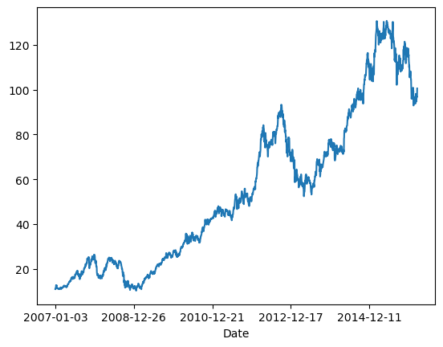

```python
#7
stock.AAPL.plot()
```

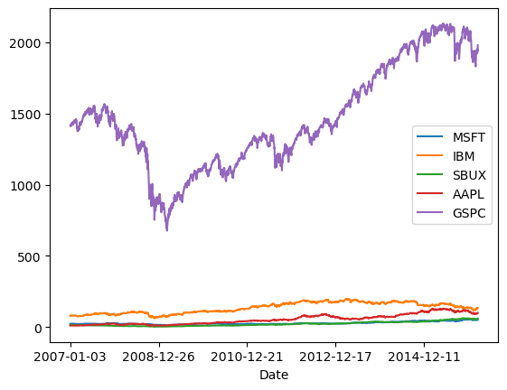

```python
#8 I
stock.plot()
```

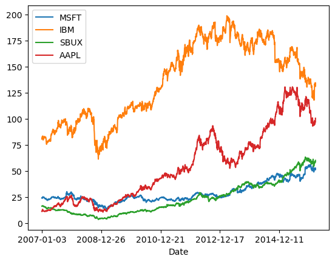

```python
#8 II
stock.iloc[:, :-1].plot()
```

```python
#9 I
stock["Year"] = pd.to_datetime(stock.index)
stock.Year = stock.Year.dt.year
stock
```

| Date | MSFT | IBM | SBUX | AAPL | GSPC | Year |
| --- | --- | --- | --- | --- | --- | --- |
| 2007-01-03 | 23.950705 | 80.517962 | 16.149666 | 11.086612 | 1416.599976 | 2007 |
| 2007-01-04 | 23.910599 | 81.378851 | 16.167992 | 11.332687 | 1418.339966 | 2007 |
| 2007-01-05 | 23.774242 | 80.642129 | 16.099269 | 11.251984 | 1409.709961 | 2007 |
| 2007-01-08 | 24.006852 | 81.867244 | 16.039710 | 11.307550 | 1412.839966 | 2007 |
| 2007-01-09 | 24.030914 | 82.835742 | 15.970989 | 12.246870 | 1412.109985 | 2007 |
| ... | ... | ... | ... | ... | ... | ... |
| 2016-02-24 | 51.360001 | 132.800003 | 58.110001 | 96.099998 | 1929.800049 | 2016 |
| 2016-02-25 | 52.099998 | 134.500000 | 58.750000 | 96.760002 | 1951.699951 | 2016 |
| 2016-02-26 | 51.299999 | 132.029999 | 58.340000 | 96.910004 | 1948.050049 | 2016 |
| 2016-02-29 | 50.880001 | 131.029999 | 58.209999 | 96.690002 | 1932.229980 | 2016 |
| 2016-03-01 | 52.580002 | 134.369995 | 60.040001 | 100.529999 | 1978.349976 | 2016 |

2306 rows × 6 columns

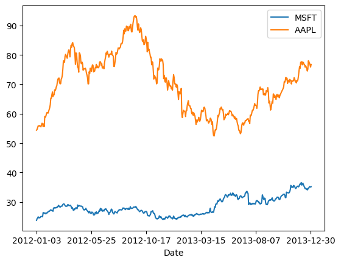

```python
#9 II
filtro1213 = (stock.Year == 2012) | (stock.Year == 2013)
stock.loc[filtro1213,["MSFT","AAPL"]].plot()
```

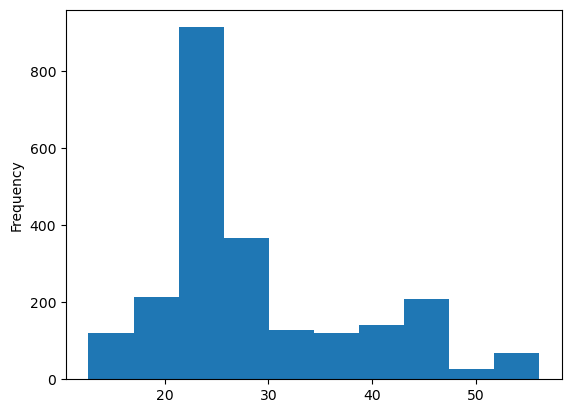

```python
#10
stock.MSFT.plot(kind="hist")
```

Esercizio Scarichiamo il dataset metal_bands_2017.csv da https://www.kaggle.com/datasets/mrpantherson/metal-by-nation e: 11• Con Seaborn visualizziamo l'istogramma del numero dei fan delle varie band; cosa si vede? Cose ne deduciamo? 12• Delle band che suonano sia Progressive che Thrash, realizziamo un barplot che mostri quanti fan ci sono in totale rispetto al paese di origine (nota: in questo caso specifico, per accedere alla colonna "style" dovremo usare ["style"] e non .style perché quest'ultimo è un metodo) 13• Visualizziamo un istogramma delle date di formazione delle band (potremo dover convertire in qualche modo questo dato); si nota qualche trend?

```python
metal = pd.read_csv("metal_bands_2017.csv", encoding="latin1", index_col=0)
metal
```

|  | band_name | fans | formed | origin | split | style |
| --- | --- | --- | --- | --- | --- | --- |
| 0 | Iron Maiden | 4195 | 1975 | United Kingdom | - | New wave of british heavy,Heavy |
| 1 | Opeth | 4147 | 1990 | Sweden | 1990 | Extreme progressive,Progressive rock,Progressive |
| 2 | Metallica | 3712 | 1981 | USA | - | Heavy,Bay area thrash |
| 3 | Megadeth | 3105 | 1983 | USA | 1983 | Thrash,Heavy,Hard rock |
| 4 | Amon Amarth | 3054 | 1988 | Sweden | - | Melodic death |
| ... | ... | ... | ... | ... | ... | ... |
| 4995 | Atara | 0 | 2006 | France | 2006 | Black,Grindcore |
| 4996 | Avicularia | 0 | 2003 | Croatia | - | Avantgarde death |
| 4997 | Awake | 0 | 2006 | United Kingdom | 2006 | Heavy,Progressive |
| 4998 | Axatak | 0 | 1983 | Australia | 1988 | Hard rock,Heavy |
| 4999 | Axis Of Despair | 0 | 2014 | Sweden | 2014 | Grindcore |

5000 rows × 6 columns

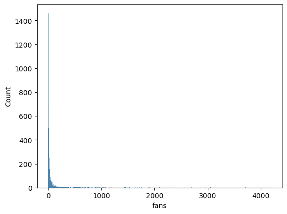

```python
#11
sns.histplot(data=metal, x="fans")
```

```python
#12
filtro_genere = metal["style"].str.contains("Progressive") | metal["style"].str.contains("Thrash")
metal_pt = metal.loc[filtro_genere]
```

```python
metal_pt.shape
```

```
(988, 6)
```

```python
metal.shape
```

```
(5000, 6)
```

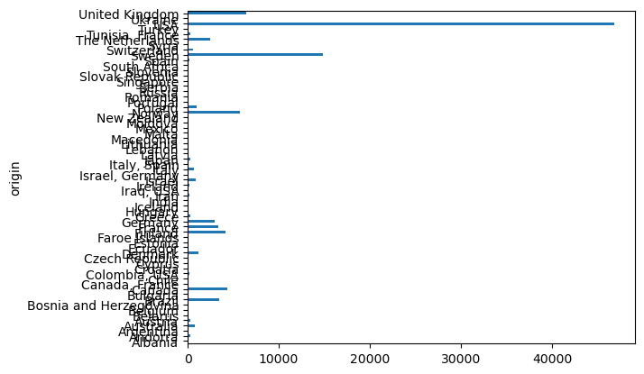

```python
metal_pt_g = metal_pt.groupby("origin")
fan_origin = metal_pt_g.fans.sum()
fan_origin.plot(kind="barh")
```

```python
#13
filtro_anno = metal.formed.str.contains("-")
filtro_anno = 	~filtro_anno
metal_anno = metal.loc[filtro_anno]
metal_anno.formed = metal_anno.formed.apply(int)
```

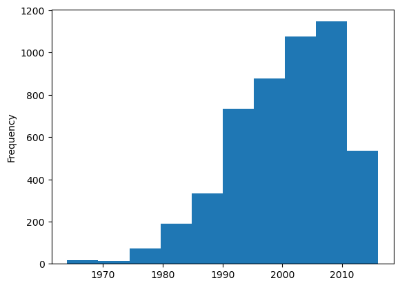

```python
metal_anno.formed.plot(kind="hist")
```

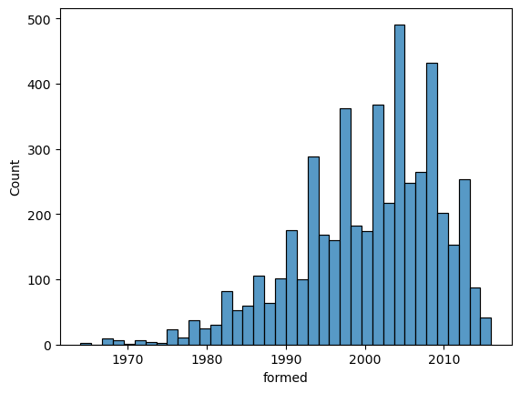

```python
sns.histplot(data=metal_anno, x="formed")
```

Esercizio Scarichiamo il dataset elections.csv da https://github.com/plotly/datasets/blob/master/election.csv: 14• Con un grafico a barre confrontiamo i voti totali presi dai tre candidati (come somma di tutti i distretti) 15• Con un grafico a barre confrontiamo il numero di votanti per ogni distretto 16• Visualizzare un grafico a barre comparativo dove si confrontano i voti presi nei primi 4 distretti per ogni candidato

```python
ele = pd.read_csv("election.csv")
ele.head(8)
```

|  | district | Coderre | Bergeron | Joly | total | winner | result | district_id |
| --- | --- | --- | --- | --- | --- | --- | --- | --- |
| 0 | 101-Bois-de-Liesse | 2481 | 1829 | 3024 | 7334 | Joly | plurality | 101 |
| 1 | 102-Cap-Saint-Jacques | 2525 | 1163 | 2675 | 6363 | Joly | plurality | 102 |
| 2 | 11-Sault-au-Récollet | 3348 | 2770 | 2532 | 8650 | Coderre | plurality | 11 |
| 3 | 111-Mile-End | 1734 | 4782 | 2514 | 9030 | Bergeron | majority | 111 |
| 4 | 112-DeLorimier | 1770 | 5933 | 3044 | 10747 | Bergeron | majority | 112 |
| 5 | 113-Jeanne-Mance | 1455 | 3599 | 2316 | 7370 | Bergeron | plurality | 113 |
| 6 | 12-Saint-Sulpice | 3252 | 2521 | 2543 | 8316 | Coderre | plurality | 12 |
| 7 | 121-La Pointe-aux-Prairies | 5456 | 1760 | 3330 | 10546 | Coderre | majority | 121 |

```python
#14
candidates = ele.loc[:,["Coderre", "Bergeron", "Joly"]]
candidates
```

|  | Coderre | Bergeron | Joly |
| --- | --- | --- | --- |
| 0 | 2481 | 1829 | 3024 |
| 1 | 2525 | 1163 | 2675 |
| 2 | 3348 | 2770 | 2532 |
| 3 | 1734 | 4782 | 2514 |
| 4 | 1770 | 5933 | 3044 |
| 5 | 1455 | 3599 | 2316 |
| 6 | 3252 | 2521 | 2543 |
| 7 | 5456 | 1760 | 3330 |
| 8 | 4734 | 1879 | 2852 |
| 9 | 5737 | 958 | 1656 |
| 10 | 2979 | 3430 | 2873 |
| 11 | 1827 | 6408 | 2815 |
| 12 | 2331 | 5748 | 2788 |
| 13 | 2670 | 4962 | 3234 |
| 14 | 3673 | 3155 | 2431 |
| 15 | 3612 | 1554 | 2081 |
| 16 | 4308 | 1320 | 3959 |
| 17 | 4104 | 1459 | 2822 |
| 18 | 3931 | 882 | 1641 |
| 19 | 5387 | 1184 | 1908 |
| 20 | 2432 | 3368 | 3578 |
| 21 | 2566 | 2092 | 2438 |
| 22 | 3347 | 2562 | 3291 |
| 23 | 2476 | 2631 | 2849 |
| 24 | 1451 | 754 | 1894 |
| 25 | 1906 | 2169 | 2282 |
| 26 | 1347 | 2827 | 2271 |
| 27 | 3668 | 984 | 1220 |
| 28 | 2878 | 2666 | 2039 |
| 29 | 2201 | 5819 | 2782 |
| 30 | 2420 | 1793 | 1402 |
| 31 | 2184 | 691 | 1076 |
| 32 | 1589 | 708 | 1172 |
| 33 | 2526 | 851 | 1286 |
| 34 | 1873 | 1182 | 1232 |
| 35 | 1644 | 1950 | 1578 |
| 36 | 1548 | 1503 | 1636 |
| 37 | 1773 | 2653 | 3262 |
| 38 | 2040 | 1437 | 2648 |
| 39 | 1165 | 832 | 1266 |
| 40 | 1193 | 653 | 1157 |
| 41 | 1325 | 1205 | 1908 |
| 42 | 4201 | 1642 | 3717 |
| 43 | 3536 | 1330 | 2943 |
| 44 | 631 | 258 | 998 |
| 45 | 595 | 226 | 1068 |
| 46 | 518 | 224 | 690 |
| 47 | 332 | 131 | 326 |
| 48 | 3694 | 2589 | 3454 |
| 49 | 2746 | 3250 | 3139 |
| 50 | 1546 | 3679 | 2675 |
| 51 | 3509 | 2178 | 2338 |
| 52 | 6591 | 1085 | 1435 |
| 53 | 6229 | 780 | 1051 |
| 54 | 996 | 643 | 423 |
| 55 | 540 | 833 | 592 |
| 56 | 446 | 465 | 419 |
| 57 | 491 | 698 | 489 |

```python
vote_sum = candidates.sum()
```

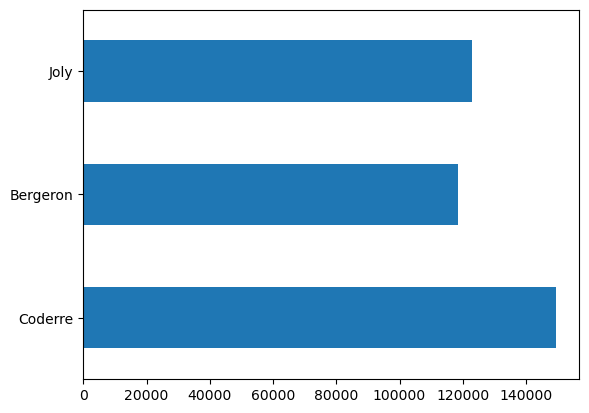

```python
vote_sum.plot(kind="barh")
```

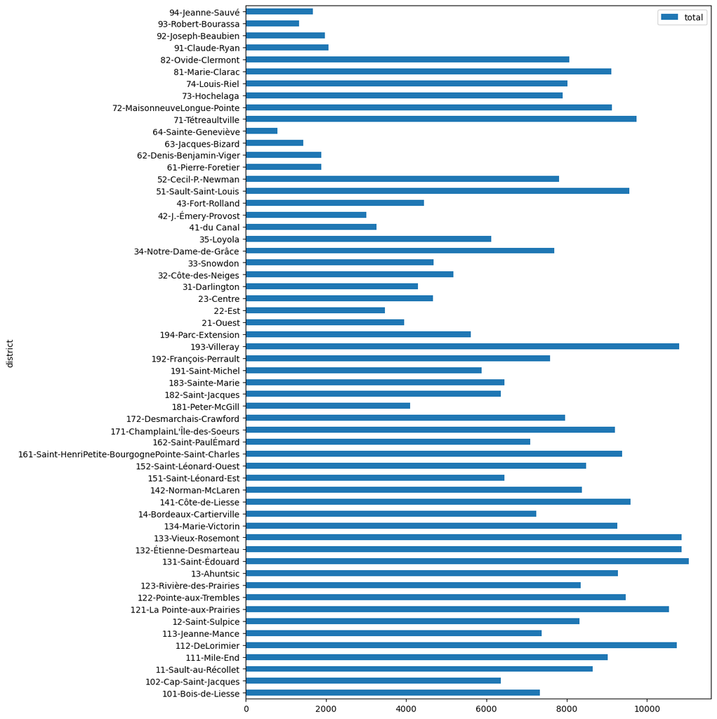

```python
#15
discrict_votes = ele.loc[:,["district", "total"]]
discrict_votes = discrict_votes.set_index("district")
discrict_votes.plot(kind="barh", figsize=[10,15])
```

```python
#16
candist = ele.loc[:,["district", "Coderre", "Bergeron", "Joly"]]
candist = ele.set_index("district")
candist = candist.iloc[:4]
candist
```

| district | Coderre | Bergeron | Joly | total | winner | result | district_id |
| --- | --- | --- | --- | --- | --- | --- | --- |
| 101-Bois-de-Liesse | 2481 | 1829 | 3024 | 7334 | Joly | plurality | 101 |
| 102-Cap-Saint-Jacques | 2525 | 1163 | 2675 | 6363 | Joly | plurality | 102 |
| 11-Sault-au-Récollet | 3348 | 2770 | 2532 | 8650 | Coderre | plurality | 11 |
| 111-Mile-End | 1734 | 4782 | 2514 | 9030 | Bergeron | majority | 111 |

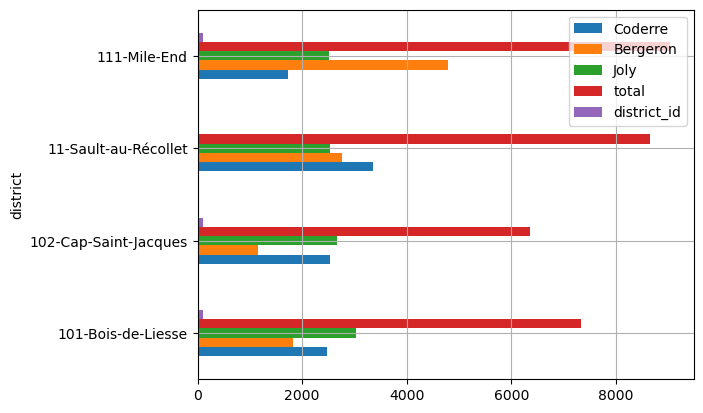

```python
candist.plot(kind="barh", grid="True")
```

Esercizio Scarichiamo i file party_in_nyc.csv dal dataset https://www.kaggle.com/datasets/somesnm/partynyc relativo a quante volte è stata chiamata la polizia per delle feste eccessivamente rumorose: 17• Realizziamo un grafico che mostra quante chiamate ci sono state per ogni città per tutti i tipi di locale 18• Qual è il rettangolo di latitudine e longitudine considerato dal dataset? 19• Quante segnalazioni sono state fatte per case private? 20• Con Seaborn visualizziamo il conteggio delle segnalazioni avvenute in ogni quartiere; che succede se aggiungiamo il parametro hue="Location Type"?

```python
party = pd.read_csv("party_in_nyc.csv")
party.shape
```

```
(225414, 8)
```

```python
party.head()
```

|  | Created Date | Closed Date | Location Type | Incident Zip | City | Borough | Latitude | Longitude |
| --- | --- | --- | --- | --- | --- | --- | --- | --- |
| 0 | 2015-12-31 00:01:15 | 2015-12-31 03:48:04 | Store/Commercial | 10034.0 | NEW YORK | MANHATTAN | 40.866183 | -73.918930 |
| 1 | 2015-12-31 00:02:48 | 2015-12-31 04:36:13 | Store/Commercial | 10040.0 | NEW YORK | MANHATTAN | 40.859324 | -73.931237 |
| 2 | 2015-12-31 00:03:25 | 2015-12-31 00:40:15 | Residential Building/House | 10026.0 | NEW YORK | MANHATTAN | 40.799415 | -73.953371 |
| 3 | 2015-12-31 00:03:26 | 2015-12-31 01:53:38 | Residential Building/House | 11231.0 | BROOKLYN | BROOKLYN | 40.678285 | -73.994668 |
| 4 | 2015-12-31 00:05:10 | 2015-12-31 03:49:10 | Residential Building/House | 10033.0 | NEW YORK | MANHATTAN | 40.850304 | -73.938516 |

```python
party["Location Type"].unique()
```

```
array(['Store/Commercial', 'Residential Building/House',
       'Club/Bar/Restaurant', 'Street/Sidewalk', 'Park/Playground',
       'House of Worship'], dtype=object)
```

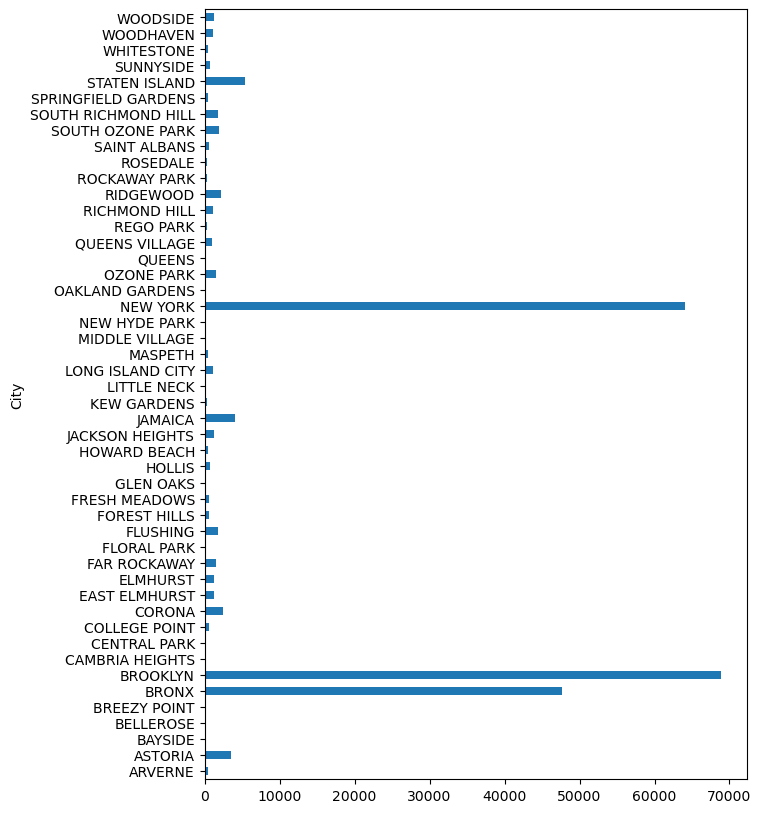

```python
#17 I
city_g = party.groupby("City")
city_g.Borough.count().plot(kind="barh", figsize=[7,10])
```

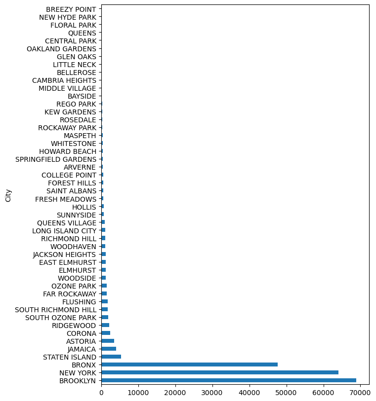

```python
#II
party.City.value_counts().plot(kind="barh", figsize=[7,10])
```

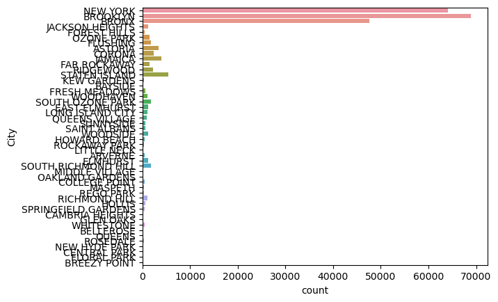

```python
#III
sns.countplot(data=party, y="City")
```

```python
party.info()
```

```
<class 'pandas.core.frame.DataFrame'>
RangeIndex: 225414 entries, 0 to 225413
Data columns (total 8 columns):
 #   Column         Non-Null Count   Dtype
---  ------         --------------   -----
 0   Created Date   225414 non-null  object
 1   Closed Date    224619 non-null  object
 2   Location Type  225414 non-null  object
 3   Incident Zip   224424 non-null  float64
 4   City           224424 non-null  object
 5   Borough        225414 non-null  object
 6   Latitude       223946 non-null  float64
 7   Longitude      223946 non-null  float64
dtypes: float64(3), object(5)
memory usage: 13.8+ MB
```

```python
party.isna().sum()
```

```
Created Date        0
Closed Date       795
Location Type       0
Incident Zip      990
City              990
Borough             0
Latitude         1468
Longitude        1468
dtype: int64
```

```python
#18 indicate nel min e max di lat e long
party.describe()
```

|  | Incident Zip | Latitude | Longitude |
| --- | --- | --- | --- |
| count | 224424.000000 | 223946.000000 | 223946.000000 |
| mean | 10720.020992 | 40.749730 | -73.924889 |
| std | 576.827879 | 0.082068 | 0.063779 |
| min | 83.000000 | 40.498820 | -74.251277 |
| 25% | 10039.000000 | 40.684648 | -73.958245 |
| 50% | 10469.000000 | 40.739170 | -73.929713 |
| 75% | 11225.000000 | 40.829273 | -73.893299 |
| max | 11697.000000 | 40.912178 | -73.702303 |

```python
#19 I
filtro_casa = party["Location Type"] == "Residential Building/House"
party.loc[filtro_casa, "Location Type"].shape
```

```
(146040,)
```

```python
#II
party["Location Type"].value_counts()
```

```
Location Type
Residential Building/House    146040
Street/Sidewalk                42353
Store/Commercial               17617
Club/Bar/Restaurant            15766
Park/Playground                 3036
House of Worship                 602
Name: count, dtype: int64
```

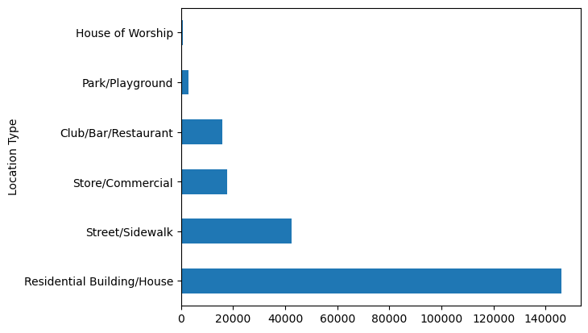

```python
party["Location Type"].value_counts().plot(kind="barh")
```

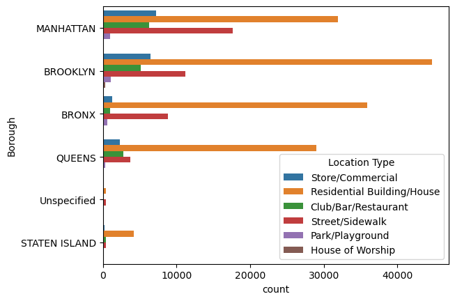

```python
#20
sns.countplot(data=party, y="Borough", hue="Location Type")
```